# RETI Engine: knowledge base

NSF Regional Innovation Engines, Cohort 2. Technology profile v3.1. Draft, in progress

**NSF RETI Engine in West Virginia and western Pennsylvania**, led by West Virginia University Research Corporation. NSF award 2532458, start August 2026. Search window for papers and patents: from August 2021 (five years before the award) onward.

## At a glance

| Measure | Value |
| --- | --- |
| People named by NSF or the Engine’s site | 8 |
| of them active researchers (>= 5 works since window start) | 0 |
| Team members who are inventors (2021-2025 grants, in the region) | 0 |
| Partners (site list + team members’ organisations) | 73 |
| Knowledge-producer partners (universities, labs, institutes) | 9 |
| Partner papers in the Engine’s topics | 2040 |
| of them with an in-region partner | 909 |
| Regional patents in the technology profile (2021-2025 grants) | 143 |
| Location quotient of the technology profile (patents) | 0.95 |
| Share of regional technology patents owned by partners | 7.7% |

## Economic base

| NAICS | Industry | Employment in region | Establishments | Share of US employment | Employment LQ |
| --- | --- | --- | --- | --- | --- |
| 2211 | Electric power generation, transmission and distribution | 24,858 | 609 | 4.8% | 1.07 |
| 331 | Primary metal manufacturing | 37,324 | 329 | 10.5% | 2.35 |
| 325 | Chemical manufacturing | 49,675 | 693 | 5.4% | 1.22 |
| 3359 | Other electrical equipment and components (incl. batteries) | 15,128 | 100 | 9.9% | 2.21 |

Industries related to the Engine’s technology (chosen from the NSF abstract, see `data/manual/engine_naics.csv`). County Business Patterns 2023; LQ = the industry’s share of regional employment relative to its share of US employment (1 = US average). Region: whole state(s).

## Technology profile

Version 3.1, core. The NSF abstract names 3 technologies of this Engine (scientific and technical fragments extracted with a fixed prompt; the extraction was done by hand in a chat session, not reproducible). For each technology, all 4,516 OpenAlex topics and all CPC main groups are ranked by several independent signals; the core keeps up to 2 topics and 2 CPC main groups per technology. *Judge*: chosen by a rubric judge where no candidate was confirmed by two kinds of evidence (also by hand in a chat session). An empty cell: no suitable item among the candidates. See Methodology and the comparison of versions.

| # | Technology | OpenAlex topics | CPC main groups |
| --- | --- | --- | --- |
| 1 | electrical grid management and control systems | T12451 Smart Grid and Power Systems T10603 Smart Grid Energy Management | H02J13/00 Circuit arrangements for providing remote monitoring or remote control of equipment in a power distribution network (judge) Y04S10/00 Systems supporting electrical power generation, transmis… |
| 2 | industrial energy systems, iron reduction and catalytic systems | T11837 Iron and Steelmaking Processes T10495 Catalysts for Methane Reforming | C21B13/00 Making spongy iron or liquid steel, by direct processes |
| 3 | energy storage, advanced batteries and solid oxide fuel cells | T10311 Advancements in Solid Oxide Fuel Cells | H01M8/00 Fuel cells; Manufacture thereof |

## People

| Role | People |
| --- | --- |
| organizer | 6 |
| researcher | 2 |

| Name | Role | On NSF award | Title | Organisation | Works since window (in Engine topics) | h-index | Patents 2021-25 (in Engine profile) | Site | OpenAlex |
| --- | --- | --- | --- | --- | --- | --- | --- | --- | --- |
| Rob Cunningham | researcher | Co-PI | Director of Grid Innovation, Co-PI | RETI Consortium | - | - |  | [page](https://reticonsortium.org/about-us/) |  |
| Sam Taylor | researcher |  | Chief Technology Officer | RETI Consortium | - | - |  | [page](https://reticonsortium.org/about-us/) |  |
| Erienne Olesh | organizer | PI | CEO | RETI Consortium | 1 (0) | 4 |  | [page](https://reticonsortium.org/about-us/) | [profile](https://openalex.org/A5005509559) |
| Liz Vitullo | organizer |  | Chief Workforce Officer | RETI Consortium | - | - |  | [page](https://reticonsortium.org/about-us/) |  |
| Matt Harbaugh | organizer | Co-PI | Director of Capital, Co-PI | RETI Consortium | - | - |  | [page](https://reticonsortium.org/about-us/) |  |
| Michelle Taylor | organizer |  | Chief Engagement Officer | RETI Consortium | - | - |  | [page](https://reticonsortium.org/about-us/) |  |
| Reed McManigle | organizer |  | Chief Commercialization Officer | RETI Consortium | - | - |  | [page](https://reticonsortium.org/about-us/) |  |
| Valerie Karplus | organizer | Co-PI | Director of Policy, Co-PI | RETI Consortium | - | - |  | [page](https://reticonsortium.org/about-us/) |  |

Publication counts are shown only where the OpenAlex author matches both the name and the person’s current organisation. The OpenAlex link is given only for these reliable matches, and not for profiles flagged as possibly merging several namesakes. *Site* links to the page of the Engine’s website where the person is named. Click a number of works to see the list on the Publications page. *Patents*: US grants 2021-2025 with the person among the inventors (same last and first name, address in the Engine’s states); click the number for the list on the Patents page. In brackets: works in the Engine’s topics, patents with a CPC code in the Engine’s technology profile.

## Researchers at partner organisations

| # | Researcher | Partner | Works in the Engine’s topics | Citations | Years | Most cited of these works |
| --- | --- | --- | --- | --- | --- | --- |
| 1 | [Anurag Kumar Srivastava](https://openalex.org/A5028171150) | West Virginia University | 57 | 913 | 2021-2026 | [Distributed Optimization in Distribution Systems: Use Cas…](https://openalex.org/W4206464364) |
| 2 | [Harry Abernathy](https://openalex.org/A5010030855) | National Energy Technology Laboratory | 56 | 382 | 2021-2026 | [Oxidation of nickel in solid oxide cells during electroch…](https://openalex.org/W4362473471) |
| 3 | [Petrus Christiaan Pistorius](https://openalex.org/A5083793252) | Carnegie Mellon University | 47 | 149 | 2021-2026 | [Chemical Composition Modification of Inclusions in Steels…](https://openalex.org/W3193664463) |
| 4 | [Xingbo Liu](https://openalex.org/A5050285671) | West Virginia University | 45 | 870 | 2021-2026 | [High-Entropy Perovskite as a High-Performing Chromium-Tol…](https://openalex.org/W4280494366) |
| 5 | [Jianli Hu](https://openalex.org/A5079109786) | West Virginia University | 38 | 636 | 2021-2026 | [Methane Catalytic Pyrolysis by Microwave and Thermal Heat…](https://openalex.org/W4226536133) |
| 6 | [Shawn Litster](https://openalex.org/A5011329420) | Carnegie Mellon University; National Energy Technology Laboratory | 34 | 321 | 2021-2026 | [Predicting PEMFC performance from a volumetric image of c…](https://openalex.org/W4387324747) |
| 7 | [Gregory Hackett](https://openalex.org/A5054784393) | National Energy Technology Laboratory | 34 | 195 | 2022-2026 | [Multiphysics modeling of SOFC performance degradation cau…](https://openalex.org/W4306931924) |
| 8 | [Wenyuan Li](https://openalex.org/A5100360800) | West Virginia University | 32 | 630 | 2022-2026 | [High-Entropy Perovskite as a High-Performing Chromium-Tol…](https://openalex.org/W4280494366) |
| 9 | [William K. Epting](https://openalex.org/A5027657732) | National Energy Technology Laboratory | 31 | 117 | 2022-2026 | [Modeling Ni Redistribution in the Fuel Electrode of Solid…](https://openalex.org/W4292675298) |
| 10 | [Wissam Abdo Saidi](https://openalex.org/A5054623889) | National Energy Technology Laboratory; University of Pittsburgh | 29 | 146 | 2022-2026 | [Conformally coated scaffold design using water-tolerant P…](https://openalex.org/W4411900631) |
| 11 | [Debangsu Bhattacharyya](https://openalex.org/A5037148093) | West Virginia University | 25 | 292 | 2022-2026 | [Techno-economic and environmental impacts assessments of …](https://openalex.org/W4401535492) |
| 12 | [Yinkai Lei](https://openalex.org/A5027213830) | National Energy Technology Laboratory | 24 | 121 | 2022-2025 | [Oxidation of nickel in solid oxide cells during electroch…](https://openalex.org/W4362473471) |
| 13 | [Brandon Robinson](https://openalex.org/A5086198298) | West Virginia University | 23 | 343 | 2022-2026 | [Methane Catalytic Pyrolysis by Microwave and Thermal Heat…](https://openalex.org/W4226536133) |
| 14 | [Douglas R. Kauffman](https://openalex.org/A5052970517) | National Energy Technology Laboratory | 21 | 114 | 2022-2026 | [Breaking the Limit of Size-Dependent CO2RR Selectivity in…](https://openalex.org/W4388560804) |
| 15 | [Changle Jiang](https://openalex.org/A5048420505) | West Virginia University | 20 | 349 | 2022-2026 | [Methane Catalytic Pyrolysis by Microwave and Thermal Heat…](https://openalex.org/W4226536133) |

The grant names mostly managers; the technology is often developed at the partner universities and labs. These are the authors with the most works in the Engine’s OpenAlex topics written at a knowledge-producer partner in the Engine’s states, since the window start (at least 3 works; top 15). The list depends on the technology profile version. OpenAlex sometimes merges namesakes into one author: check the profile before relying on a name.

## Partners

| Organisation class | Partners |
| --- | --- |
| company | 30 |
| intermediary | 13 |
| investor | 13 |
| university | 6 |
| government | 5 |
| community_college | 2 |
| research_institute | 2 |
| national_lab | 1 |
| philanthropy | 1 |

Partner list on the site: *Complete logo wall (77 logos; names from alt text)*.

| Partner | Class | State | OpenAlex works since window (all topics) |
| --- | --- | --- | --- |
| University of Pittsburgh | university | Pennsylvania | 129798 |
| Carnegie Mellon University | university | Pennsylvania | 42182 |
| West Virginia University | university | West Virginia | 27118 |
| National Laboratory of the Rockies | national_lab | Colorado | 17683 |
| Duquesne University | university | Pennsylvania | 3526 |
| National Energy Technology Laboratory | research_institute | Pennsylvania | 3357 |
| Electric Power Research Institute | research_institute | California | 1822 |
| West Virginia State University | university | West Virginia | 422 |
| West Virginia University Institute of Technology | university | West Virginia | 218 |

## Science base: partner papers in the Engine’s topics

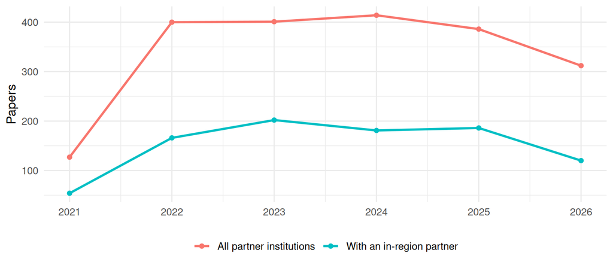

| Partner | Papers in topics |
| --- | --- |
| National Laboratory of the Rockies | 1025 |
| National Energy Technology Laboratory | 366 |
| West Virginia University | 259 |
| Carnegie Mellon University | 245 |
| Electric Power Research Institute | 153 |
| University of Pittsburgh | 91 |
| Duquesne University | 5 |
| West Virginia University Institute of Technology | 5 |
| West Virginia State University | 1 |

## Technology base: patents

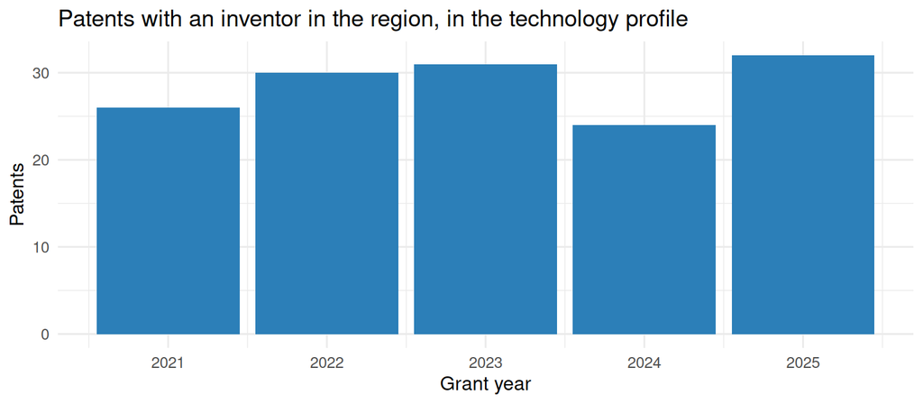

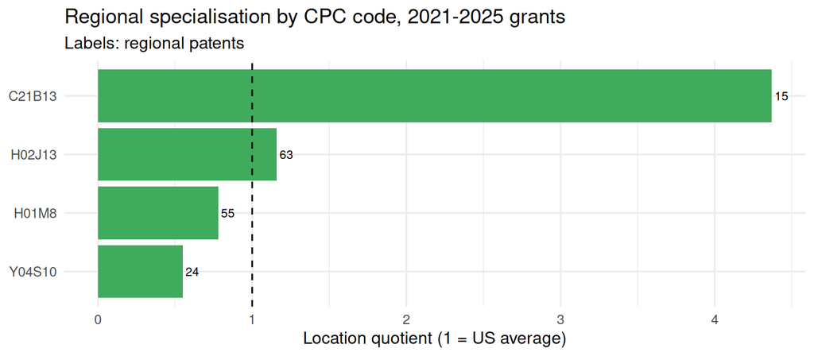

| Assignee | Regional patents in profile |
| --- | --- |
| Lutron Technology Company LLC | 24 |
| Watt Fuel Cell Corp. | 11 |
| SUNCOKE TECHNOLOGY AND DEVELOPMENT LLC | 7 |
| Sapient Industries, Inc. | 6 |
| Aclara Technologies LLC | 4 |
| EATON INTELLIGENT POWER LIMITED | 4 |
| University of Pittsburgh—Of the Commonwealth System of Higher Education | 4 |
| BLOOM ENERGY CORPORATION | 3 |
| ExxonMobil Technology and Engineering Company | 3 |
| THE PENN STATE RESEARCH FOUNDATION | 3 |

Partner-owned patents invented in the region: 1065, of which 11 (1.0%) fall in the Engine’s technology profile.

## Competition

With 143 patents in the technology profile (2021-2025 grants), the Engine’s region would rank **10** among US states; its specialisation (LQ) is 0.947.

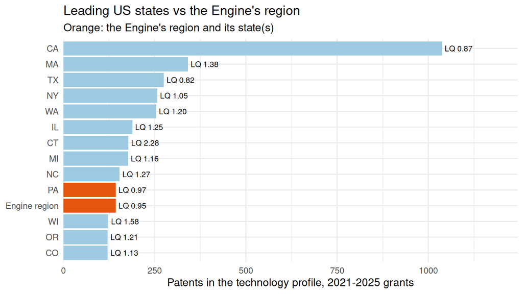

| Country | Share of US patents in profile | Share of world papers in topics |
| --- | --- | --- |
| US | 41.3% | 7.4% |
| JP | 22.3% | 2.5% |
| KR | 10.3% | 2.5% |
| DE | 7.4% | 3.4% |
| CN | 5.9% | 33.6% |
| CA | 3.2% | 1.7% |
| GB | 2.7% | 2.9% |
| FR | 2.3% | 1.9% |
| IN | 1.7% | 5.8% |
| TW | 1.0% | NA |

Patents: inventor countries on US grants in the profile (a patent counts for every country of its inventors). Papers: author countries of OpenAlex works in the Engine’s topics since the window start.

## Data and limitations

- People: PIs and Co-PIs from the NSF Award API; leadership listed on the Engine’s website. Roles come from titles and organisations, revised with OpenAlex evidence.
- Partners: as listed on the Engine’s website, plus organisations of team members. Some Engines publish partner logos without names.
- Region: the Engine’s counties where the list is known (NEO-SMART: 18 Northeast Ohio counties; STELLAR: 11 counties from the NSF abstract), otherwise its states (state-level proxy).
- Technology profile: v3.1 (switch versions in the header). Partner papers and regional patents depend on it: v1 uses mostly CPC subclasses, the v3.1 core uses CPC main groups, which are narrower, so it counts fewer patents and the LQ of a small region rests on few patents.
- Papers: OpenAlex; partner papers are restricted to the Engine’s OpenAlex topics.
- Patents: USPTO grants 2021-2025; inventor locations from PatentsView; pre-grant publications are not included.